# Applications of Item Response Theory in *R*

W. Jake Thompson, Ph.D.

2020-02-23

This document provides and overview of how to estimate a 3-parameter logistic (3PL) item response theory (IRT) model in *R*. For illustrative purposes, we also limit this example to dichotomously scored items in order to simplify the problem while learning the software. A more complete example with polytomous items and additional analyses (e.g., information, reliability, model fit, etc.) can be found in the `full-example` directory. Most data cleaning and manipulation will utilize a suite a packages known as the **tidyverse** (Wickham et al., 2019). The IRT analysis will use the **mirt** package (Chalmers, 2012).

## Data Cleaning

The first step of any analysis is to read in the data. For this example, we will use a balanced sample of males and females from a large scale operational assessment. This data set contains 5,000 respondents to 40 items assessing the respondents’ knowledge and understandings of engineering design. Also included is a file of metadata, describing the 40 items.

```r
ied <- read_csv(here("data", "IED_data.csv"),
                col_types = cols(.default = col_integer(),
                                 gender = col_character()))
meta <- read_excel(here("data", "metadata.xlsx"), sheet = "IED")
```

Because we want to use only dichotomously scored items, we need to remove any polytomous items from the data set. In the `meta` data, the `NIS` variable includes the number of score categories. To identify the dichotomous items, we can pull the `itemid`s for cases where `NIS` is equal to 2.

```r
dichot_items <- meta %>%
  filter(NIS == 2) %>%
  pull(itemid) %>%
  as.character()
```

We can then create a new data set for modeling by selecting only the demographic variables and the dichotomous items from the `ied` data. We also need to clean the response data. In the `ied` data, missing values have been coded a `-9`. The `na_if` function can be used to replace a given value with *R*’s internal representation of missing values, `NA`.

```r
clean_ied <- ied %>%
  select(studentid, gender, {{dichot_items}}) %>%
  mutate_all(~na_if(.x, -9))
```

## Estimate IRT Model

We next have to specify how each item will be modeled. In this example, every item will be estimated using the 3PL IRT model (Birnbaum, 1968). To specify item models, we create of vector model recognized by **mirt**. Conveniently, the 3PL model is denoted `3PL`. Because all items have the same model, we create a vector that repeats `3PL` once for each item. For a list of available models, see [`?mirt()`](https://rdrr.io/cran/mirt/man/mirt.html).

```r
mirt_type <- rep("3PL", length(dichot_items))
```

To estimate the IRT model, we’ll use the **mirt** package (Chalmers, 2019). This function requires that the data include only item responses, so we’ll create a data set, `model_data`, that is the same as the original data but with the `studentid` and `gender` columns removed.

```r
model_data <- clean_ied %>%
  select(-studentid, -gender)
```

We are now ready to estimate the model. The first argument is the `data`, which we specify as the `model_data` we just created. Next, the actual model must be specified. Because we are using a unidimensional model, we have only one factor, called `F1`. This factor is measured by items 1 through the number of columns in our `model_data`, in this case, 29. We can then specify prior distributions for each parameter. This makes the estimation more efficient by setting reasonable distributions we might expect the item parameters to fall within. The **mirt** package defines the IRT model using the slope intercept form shown equation (1).

$$\begin{equation}
\Pr(Y_{ij}=1|\alpha_i, \beta_i, \gamma_i, \theta_j) =
\frac{\exp(\gamma_i)}{1 + \exp(\gamma_i)} +
\frac{1}{1 + \exp(\gamma_i)}
\frac{\exp(\alpha_i\theta_j + \beta_i)}{1 + \exp(\alpha_i\theta_j + \beta_i)}
\tag{1}
\end{equation}$$

This is in contrast to the more traditional parameterization shown in equation (2).

$$\begin{equation}
\Pr(Y_{ij}=1|a_i, b_i, c_i, \theta_j) =
c_i + (1 - c_i)
\frac{\exp\{a_i(\theta_j - b_i)\}}{1 + \exp\{a_i(\theta_j - b_i)\}}
\tag{2}
\end{equation}$$

Thus, we must define our prior on the scale of the estimated parameters in equation (1), and then transform back onto the more common parameterization. The transformation between the parameterizations in equation (1) and equation (2) is given in equation (3).

$$\begin{equation}
\begin{split}
a_i = \alpha_i
\end{split}
\quad\quad
\begin{split}
b_i = - \frac{\beta_i}{\alpha_i}
\end{split}
\quad\quad
\begin{split}
c_i = \frac{\exp(\gamma_i)}{1 + \exp(\gamma_i)}
\end{split}
\tag{3}
\end{equation}$$

For the $\alpha$ parameter, we define a lognormal prior with a mean of 0 and a standard deviation of 1. The $\beta$ parameter (called $d$ in **mirt**) is given a normal prior with a mean of 0 and a standard deviation of 2. Finally, $\gamma$ is given a normal prior with a mean of -1.39 and standard deviation. These priors for parameterization in equation (2) are shown in Figure 1.

```r
model_spec <- mirt.model("F1 = 1-29
                          PRIOR = (1-29, a1, lnorm, 0, 1),
                                  (1-29, d, norm, 0, 2),
                                  (1-29, g, norm, -1.39, 1)")
```

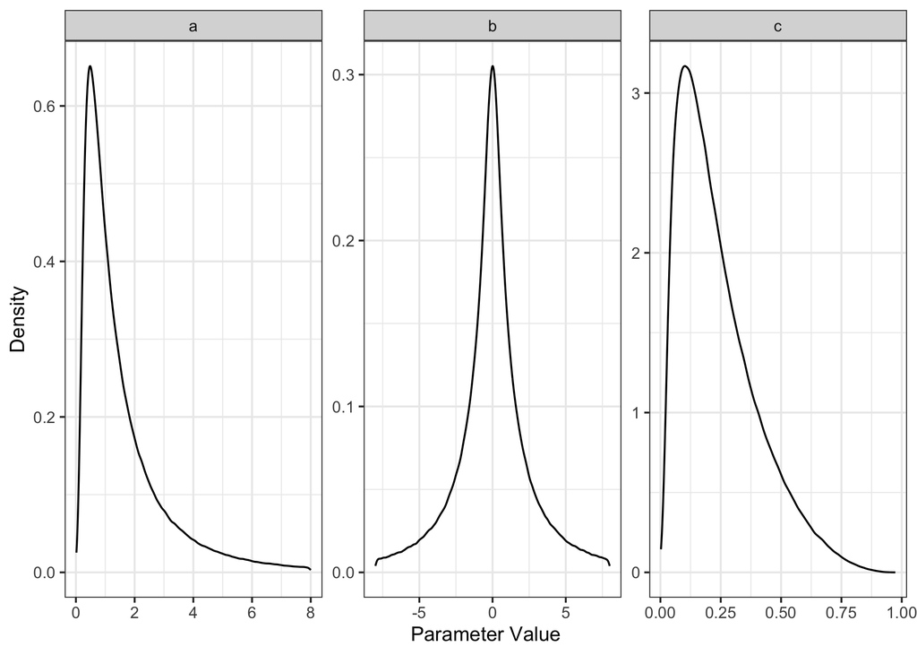

Figure 1: Prior distributions for the 3PL IRT model, as defined in `model_spec`.

Next, for each item, we specify what the item type is. We calculated this when we created the `mirt_type` vector. Finally, we’ll set a random seed to make sure we all get the same results (they should be pretty close without this).

```r
model_3pl <- mirt(data = model_data, model = model_spec,
                  itemtype = mirt_type, technical = list(set.seed = 9416))
```

Now we’ve estimated the model!

```r
model_3pl
```

```
##
## Call:
## mirt(data = model_data, model = model_spec, itemtype = mirt_type,
##     technical = list(set.seed = 9416))
##
## Full-information item factor analysis with 1 factor(s).
## Converged within 0.0001 tolerance after 35 EM iterations.
## mirt version: 1.31
## M-step optimizer: nlminb
## EM acceleration: Ramsay
## Number of rectangular quadrature: 61
## Latent density type: Gaussian
##
## Log-posterior = -70673.59
## Estimated parameters: 87
## DIC = 141521.2
```

### IRT Parameters

The default output is not incredibly useful. What we ultimately want are the estimated item and person parameters. We’ll focus first on item parameters.

#### Item Parameters

We can extract the item parameters by the using the `coef()` function. For each item, we see the slope (`a1`), intercept (`d`), and guessing parameter `g`.

```r
coef(model_3pl)
```

```
## $`2487`
##        a1      d     g u
## par 1.123 -4.146 0.241 1
##
## $`2488`
##        a1      d     g u
## par 1.324 -2.452 0.005 1
##
## $`2489`
##        a1      d     g u
## par 2.201 -1.457 0.093 1
##
## $`2491`
##       a1      d     g u
## par 0.54 -0.195 0.078 1
##
## $`2792`
##        a1      d     g u
## par 0.155 -3.028 0.193 1
##
## $`2794`
##        a1      d     g u
## par 0.459 -3.201 0.019 1
##
## $`2797`
##        a1     d     g u
## par 0.911 0.335 0.045 1
##
## $`2829`
##        a1      d     g u
## par 0.381 -5.053 0.015 1
##
## $`2830`
##        a1     d     g u
## par 2.335 1.355 0.084 1
##
## $`2831`
##        a1      d     g u
## par 0.938 -1.125 0.013 1
##
```

[output cut: 64 more lines]

```
## $`3485`
##        a1     d     g u
## par 2.883 0.609 0.015 1
##
## $`3486`
##        a1     d     g u
## par 2.939 0.765 0.013 1
##
## $`3591`
##        a1      d     g u
## par 0.354 -2.133 0.033 1
##
## $GroupPars
##     MEAN_1 COV_11
## par      0      1
```

Often, it is more useful to think about the parameters using the more well known $a$, $b$, and $c$ parameters. These can be retrieved by setting `IRTpars = TRUE`.

```r
coef(model_3pl, IRTpars = TRUE)
```

```
## $`2487`
##         a     b     g u
## par 1.123 3.693 0.241 1
##
## $`2488`
##         a     b     g u
## par 1.324 1.852 0.005 1
##
## $`2489`
##         a     b     g u
## par 2.201 0.662 0.093 1
##
## $`2491`
##        a    b     g u
## par 0.54 0.36 0.078 1
##
## $`2792`
##         a      b     g u
## par 0.155 19.518 0.193 1
##
## $`2794`
##         a     b     g u
## par 0.459 6.969 0.019 1
##
## $`2797`
##         a      b     g u
## par 0.911 -0.367 0.045 1
##
## $`2829`
##         a      b     g u
## par 0.381 13.255 0.015 1
##
## $`2830`
##         a     b     g u
## par 2.335 -0.58 0.084 1
##
## $`2831`
##         a   b     g u
## par 0.938 1.2 0.013 1
##
```

[output cut: 64 more lines]

```
## $`3485`
##         a      b     g u
## par 2.883 -0.211 0.015 1
##
## $`3486`
##         a     b     g u
## par 2.939 -0.26 0.013 1
##
## $`3591`
##         a     b     g u
## par 0.354 6.023 0.033 1
##
## $GroupPars
##     MEAN_1 COV_11
## par      0      1
```

The last problem to solve is that the coefficients are returned in a list format. This is done because, depending on the estimated model, not every item will have the same set of parameters (e.g., if we included polytomous items). Thus, for consistency, the **mirt** package always returns the parameters in a list format, which can handle any configuration of parameters. However, with some **tidyverse** magic, we can create a data frame that has one row per item since all of our items have the same set of parameters.

```r
item_params <- coef(model_3pl, IRTpars = TRUE) %>%
  list_modify(GroupPars = zap()) %>%
  imap_dfr(function(x, y) {
    as_tibble(x) %>%
      add_column(itemid = y, .before = 1) %>%
      select(itemid, a, b, everything())
  }) %>%
  rename(c = g) %>%
  replace_na(list(c = 0, u = 1))

item_params
```

```
## # A tibble: 29 x 5
##    itemid     a      b       c     u
##    <chr>  <dbl>  <dbl>   <dbl> <dbl>
##  1 2487   1.12   3.69  0.241       1
##  2 2488   1.32   1.85  0.00537     1
##  3 2489   2.20   0.662 0.0935      1
##  4 2491   0.540  0.360 0.0784      1
##  5 2792   0.155 19.5   0.193       1
##  6 2794   0.459  6.97  0.0188      1
##  7 2797   0.911 -0.367 0.0446      1
##  8 2829   0.381 13.3   0.0147      1
##  9 2830   2.33  -0.580 0.0842      1
## 10 2831   0.938  1.20  0.0130      1
## # … with 19 more rows
```

#### Person Parameters

We are also likely interested in the person parameters, or the respondent ability estimates. We can extract the ability estimates using the `fscores()` function. When then do some formatting to get the scores into a nice data frame, and add a `studentid` column so we can keep track of which ability estimate goes with each respondent.

```r
person_params <- fscores(model_3pl) %>%
  as_tibble(.name_repair = ~"theta") %>%
  rowid_to_column(var = "studentid")

person_params
```

```
## # A tibble: 5,000 x 2
##    studentid  theta
##        <int>  <dbl>
##  1         1 -0.165
##  2         2  0.470
##  3         3  1.51
##  4         4  0.175
##  5         5  1.18
##  6         6 -0.462
##  7         7 -0.160
##  8         8 -1.02
##  9         9  0.723
## 10        10  0.910
## # … with 4,990 more rows
```

## Other Methods for IRT in *R*

The **mirt** package is not the only way to estimate IRT models in *R*. Choi & Asilkalkan (2019) provides a thorough overview of 45 *R* packages that can be used to conduct analyses using IRT including differential item functioning and equating. The paper also discusses the features available in each package, making this an excellent resource when trying to find a package to complete a specific analysis.

For more advanced work and better methods for model fit, Bayesian modeling offers much more flexibility. The *Stan* probabilistic programming language (Carpenter et al., 2017) offers one way to define these models in *R* with the **rstan** package (Guo, Gabry, & Goodrich, 2019). The **brms** package also offers an interface to *Stan* for estimating linear and non-linear multilevel models, without having to learn the *Stan* language (Bürkner, 2017, 2018, 2020). Bürkner (2019) provides a comprehensive overview of how to specify, estimate, and evaluate IRT models, along with comparisons to other *R* packages.

## References

Birnbaum, A. (1968). Some latent trait models and their use in inferring an examinee’s ability. In F. M. Lord & M. R. Novick (Eds.), *Statistical theories of mental test scores* (pp. 397–479). Reading, MA: Addison-Wesley.

Bürkner, P.-C. (2017). brms: An R package for Bayesian multilevel models using Stan. *Journal of Statistical Software*, *80*(1), 1–28. https://doi.org/10.18637/jss.v080.i01

Bürkner, P.-C. (2018). Advanced Bayesian multilevel modeling with the R package brms. *The R Journal*, *10*(1), 395–411. https://doi.org/10.32614/RJ-2018-017

Bürkner, P.-C. (2019). Bayesian item response modeling in R with brms and Stan. Retrieved from http://arxiv.org/abs/1905.09501v3

Bürkner, P.-C. (2020). *brms: Bayesian regression models using ’stan’*. Retrieved from https://CRAN.R-project.org/package=brms

Carpenter, B., Gelman, A., Hoffman, M. D., Lee, D., Goodrich, B., Betancourt, M., … Riddell, A. (2017). Stan: A probabilistic programming language. *Journal of Statistical Software*, *76*. https://doi.org/10.18637/jss.v076.i01

Chalmers, P. (2019). *mirt: Multidimensional item response theory*. Retrieved from https://CRAN.R-project.org/package=mirt

Chalmers, R. P. (2012). mirt: A multidimensional item response theory package for the R environment. *Journal of Statistical Software*, *48*(6), 1–29. https://doi.org/10.18637/jss.v048.i06

Choi, Y.-J., & Asilkalkan, A. (2019). R packages for item response theory analysis: Descriptions and features. *Measurement: Interdisciplinary Research and Perspectives*, *17*, 168–175. https://doi.org/10.1080/15366367.2019.1586404

Guo, J., Gabry, J., & Goodrich, B. (2019). *RStan: R interface to Stan*. Retrieved from https://CRAN.R-project.org/package=rstan

Wickham, H., Averick, M., Bryan, J., Chang, W., McGowan, L. D., François, R., … Yutani, H. (2019). Welcome to the tidyverse. *Journal of Open Source Software*, *4*(43), 1686. https://doi.org/10.21105/joss.01686